# Data Viz Basics Exercise Answers

### Exercise 1

#### 1a

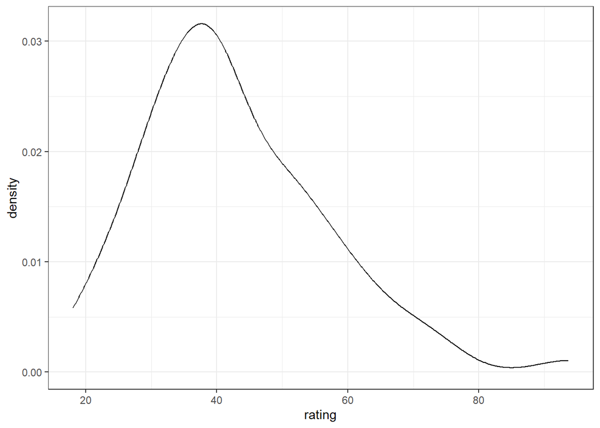

```r
ggplot(cereal, aes(x = rating)) +
  geom_density()
```

Alternatively, you can put the `aes(x = rating)` within the `geom_density()` call.

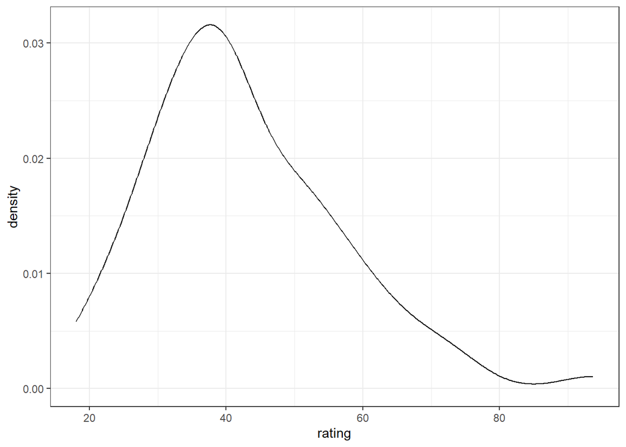

```r
ggplot(cereal) +
  geom_density(aes(x = rating))
```

#### 1b

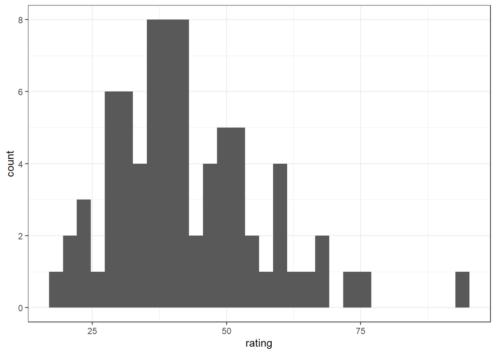

```r
ggplot(cereal, aes(x = rating)) +
  geom_histogram()
```

#### 1c

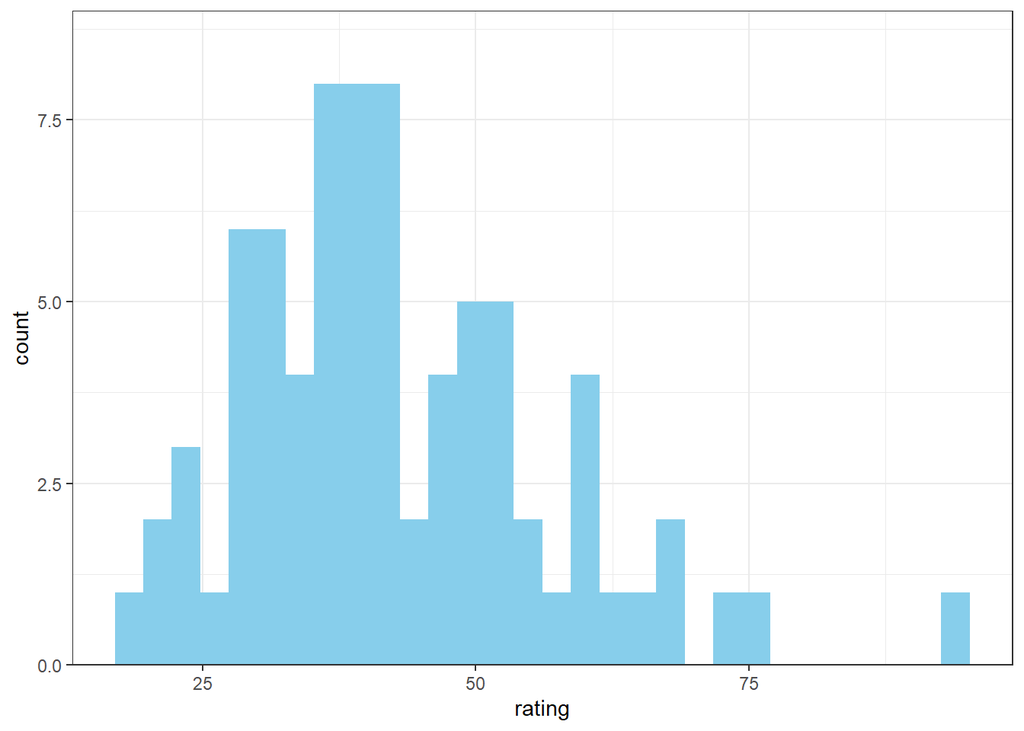

```r
ggplot(cereal, aes(x = rating)) +
  geom_histogram(fill = 'skyblue') +
  scale_y_continuous(expand = expansion(add = c(0, 1)))
```

Note that `fill = '...'` is not inside `aes()` because it does not map back to a variable in the data. It is just a stylistic choice. You may also choose other expansion parameters. I chose `add = c(0, 1)` to add 0 units of padding at the lower end and 1 unit of padding at the upper end. Unfortunately this causes non-integer breaks to appear in the y-axis by default but this could be fixed by adding, for example `breaks = c(0, 4, 8)` to the call to `scale_y_continuous()`.

### Exercise 2

#### 2a

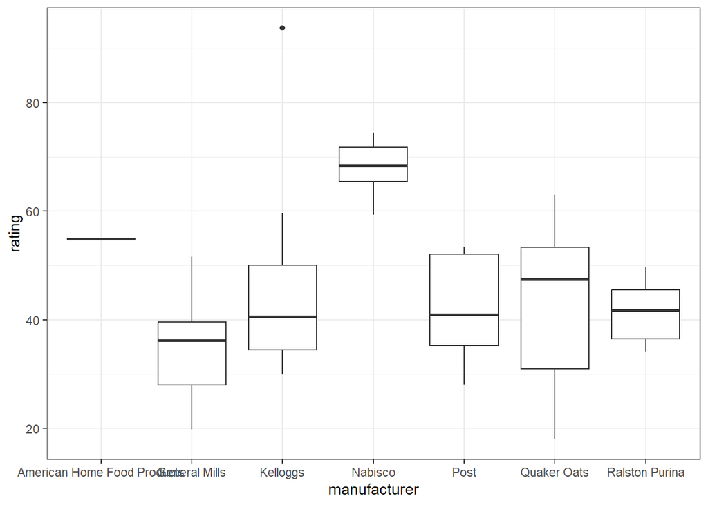

```r
ggplot(cereal, aes(x = manufacturer, y = rating)) +
  geom_boxplot()
```

#### 2b

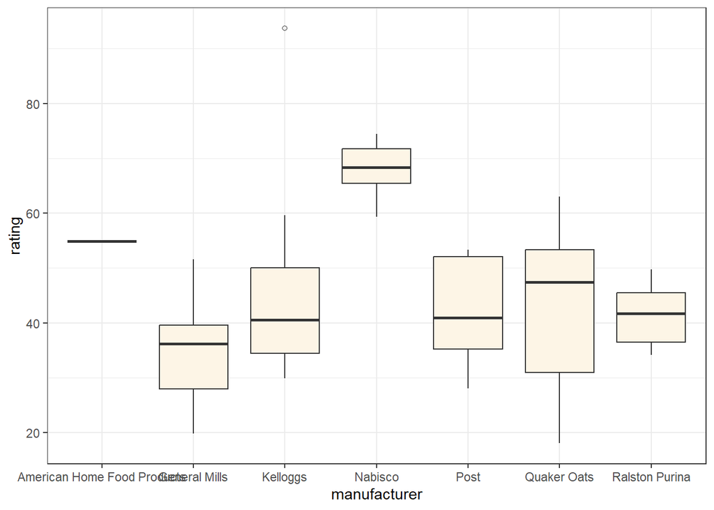

```r
ggplot(cereal, aes(x = manufacturer, y = rating)) +
  geom_boxplot(fill = 'oldlace', outlier.shape = 1)
```

*Bonus content*: You might’ve noticed that the names of the manufacturers are long and overlap one another. This can be fixed by customizing the x-axis labels so that the labels wrap onto multiple lines of text as follows. I used `width = 15` to split lines every 15 characters, but other numbers could be used.

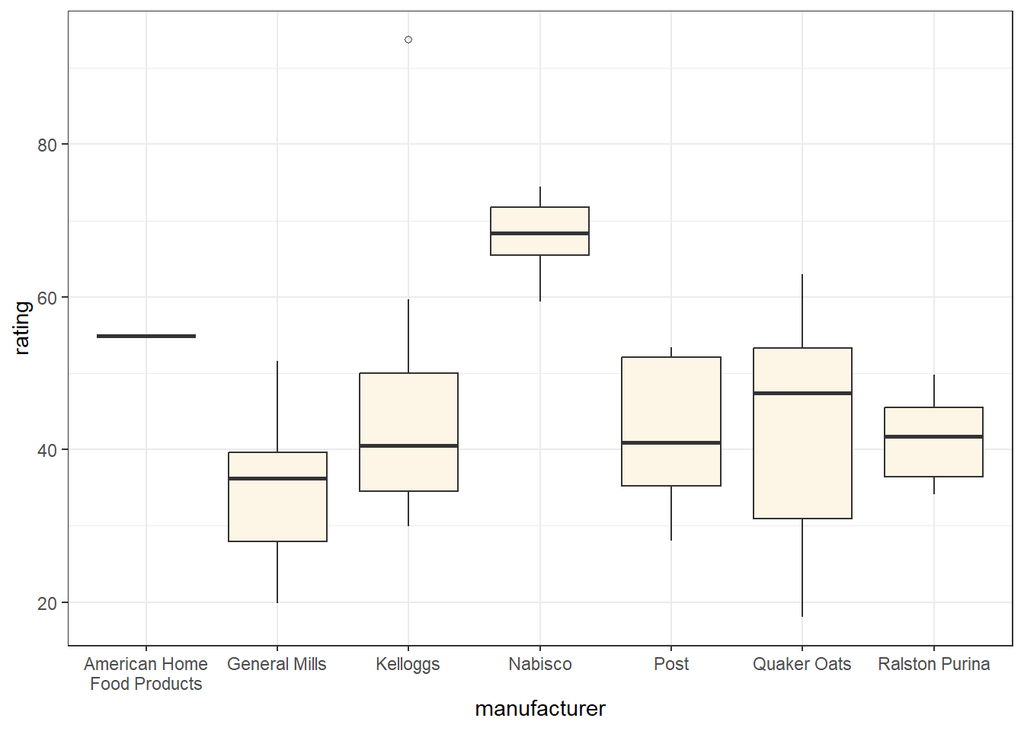

```r
ggplot(cereal, aes(x = manufacturer, y = rating)) +
  geom_boxplot(fill = 'oldlace', outlier.shape = 1) +
  scale_x_discrete(labels = function(x) stringr::str_wrap(x, width = 15))
```

### Exercise 3

#### 3a

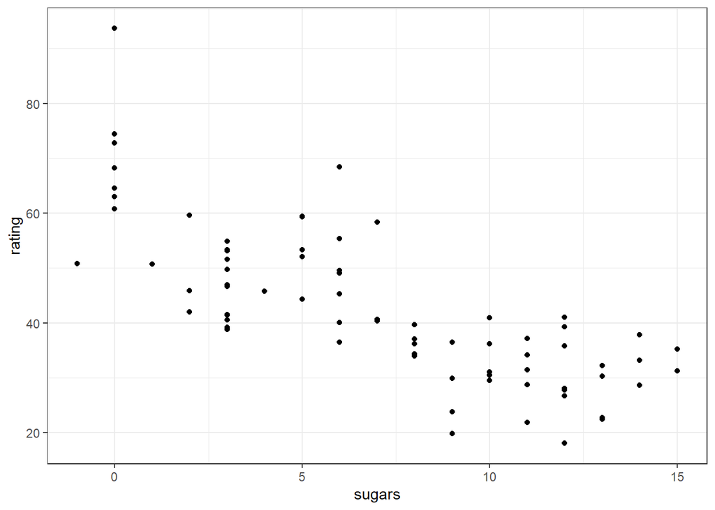

```r
ggplot(cereal, aes(x = sugars, y = rating)) +
  geom_point()
```

#### 3b

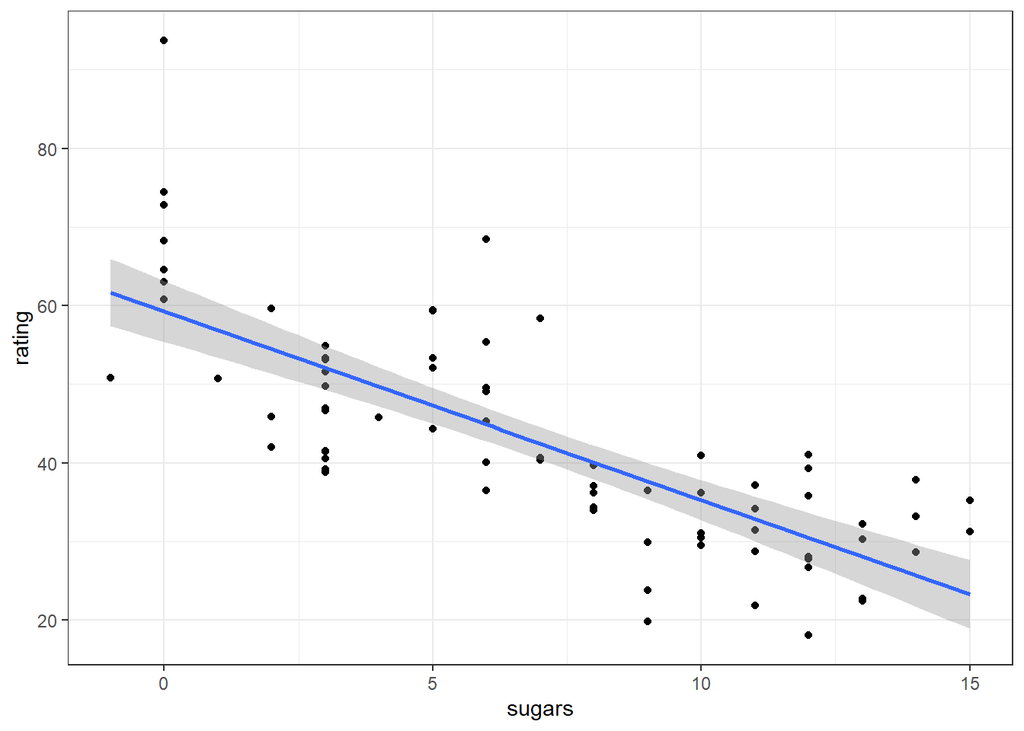

```r
ggplot(cereal, aes(x = sugars, y = rating)) +
  geom_point() +
  geom_smooth(method = lm)
```

The default for `geom_smooth()` is `se = TRUE`. The standard error around the trend is shown as a shaded region.

#### 3c

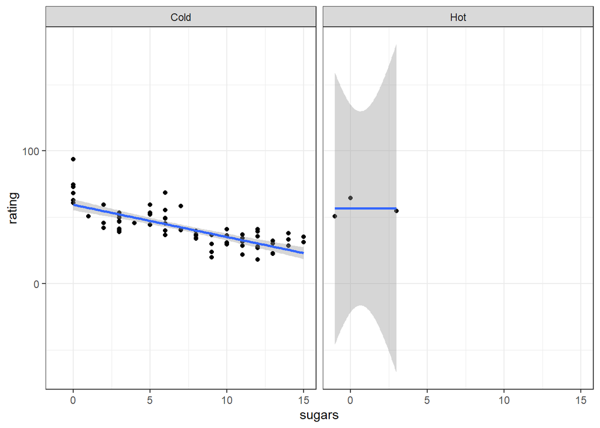

```r
ggplot(cereal, aes(x = sugars, y = rating)) +
  geom_point() +
  geom_smooth(method = lm) +
  facet_wrap( ~ type)
```

*Bonus content*: As there are only a handful of hot cereals,all with very low sugar content and moderate to high health rating, we have a lopsided looking plot. Also, the standard errors of rating extend beyond the 0-100 range. We would have to use a special model to fix that problem if we were really doing a formal analysis here. I will fix it for plotting purposes by allowing the x-axes to vary by facet (`scales = 'free_x'`) and using `coord_cartesian()` to truncate the y-axis so that the standard error envelope outside of 0-100 isn’t shown.

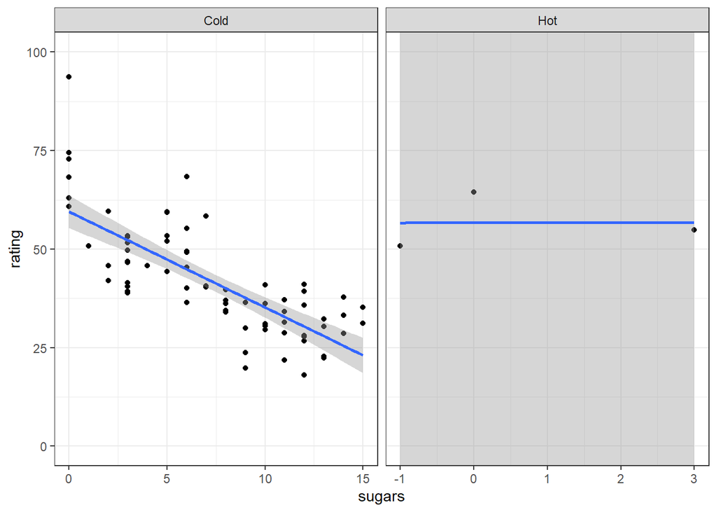

```r
ggplot(cereal, aes(x = sugars, y = rating)) +
  geom_point() +
  geom_smooth(method = lm) +
  facet_wrap(~ type, scales = 'free_x') +
  coord_cartesian(ylim = c(0, 100))
```